# PAC_4

2025-06-03

## 1 Preprocessament

### 1.1 Variables value_eur i club_name

Carregueu el fitxer de dades “female_play_net.csv”. Consulteu els tipus de dades de la variable value_eur i si és necessari, apliqueu les transformacions apropiades. Esbrineu possibles inconsistències en els valors de value_eur. En cas que existeixin inconsistències, corregiu-les. **Nota**: Si els valors de **value_eur** estan en lliures s’han de passar a euros. Considereu la següent taxa de canvi (1EU R = 0, 85£).

Elimineu la lletra W i últim espai en blanc del nom de l’equip de football **club_name**.

Primer llegim el csv i mostrem, les primeres files i columnes ja que si no la taula seria molt gran

```r
data <- read.csv("~/Documentos/GitHub/UOC-treballs/analisis_estadistic/pac4/female_play_net.csv", encoding="UTF-8")

kable(head(data[,1:5]))
```

| X | player_id | player_url | fifa_version | fifa_update |
| --- | --- | --- | --- | --- |
| 1 | 227203 | /player/227203/alexia-putellas-segura/240002 | 24 | 2 |
| 2 | 241667 | /player/241667/aitana-bonmati-conca/240002 | 24 | 2 |
| 3 | 227102 | /player/227102/caroline-graham-hansen/240002 | 24 | 2 |
| 4 | 227125 | /player/227125/sam-kerr/240002 | 24 | 2 |
| 5 | 236479 | /player/236479/maria-pilar-leon-cebrian/240002 | 24 | 2 |
| 6 | 226301 | /player/226301/alex-morgan/240002 | 24 | 2 |

Ara mirem els valors de la columna **value_eur** i veiem que es “character” quan hauria de ser numèric, això es degut a que tenim £ en alguns valors

```r
print(class(data$value_eur))
```

```
## [1] "character"
```

```r
data$value_eur[4]
```

```
## [1] "£101575000"
```

```r
library(dplyr)
library(stringr)
data <- data  %>%
  mutate(value_eur = ifelse(str_detect(value_eur,"£"), 0.85*as.numeric(substring(value_eur,2)),as.numeric(value_eur) ))
data$value_eur[4]
```

```
## [1] 86338750
```

```r
print(class(data$value_eur))
```

```
## [1] "numeric"
```

Ara eliminarem el w i el espai en blanc al final **club_name**

```r
data$club_name <- gsub(" W","",as.character(data$club_name ))
kable(head(data$club_name, 5))
```

| x |
| --- |
| Barcelona |
| Barcelona |
| Barcelona |
| Chelsea |
| Barcelona |

### 1.2 Valors absents

En aquest apartat, realitzarem tractament per a valors absents. Adoptarem la següent estratègia:

- Seleccionar únicament les observacions per a les quals la variable league_ name no és un valor absent. Denominar al conjunt de dades ffemale_full.
- Comproveu quantes observacions tenen valors absents i reflexioneu breument sobre com de preocupant és el problema de valors absents en aquestes dades.
- En cas de valors absents de la variable value_ eur en el conjunt de dades ffemale_ full, realitzeu imputació considerant la mediana de la variable value_ eur entre les jugadores del mateix equip al qual pertanyi l’observació amb valor absent.
- Elimineu _eur en el nom de les variables del conjunt de dades ffemale_full

```r
ffemale_full <- data[data$league_name != "",]
nrow(data)
```

```
## [1] 5035
```

```r
nrow(ffemale_full)
```

```
## [1] 2245
```

Veiem que hem passat de 5035 entrades a 2245 perdent mes de la meitat en fer això també veiem que tots els que treiem no tenen valors a la columna value_eur wage o club_name, sembla que es un error generalitzat per a molts valors, indicant que la font de dades te molts errors. Ara mirarem d’aquest subset quants tenen value_eur null i aplicarem la mediana del equip

```r
nrow(ffemale_full[is.na(ffemale_full$value_eur),])
```

```
## [1] 62
```

```r
library(dplyr)

ffemale_full <- ffemale_full %>%
  group_by(club_team_id) %>%
  mutate(
    value_eur = ifelse(is.na(value_eur), median(value_eur, na.rm = TRUE), value_eur)
  ) %>%
  ungroup()
nrow(ffemale_full[is.na(ffemale_full$value_eur),])
```

```
## [1] 0
```

```r
nrow(ffemale_full)
```

```
## [1] 2245
```

Veiem com ja no tenim valors amb aquestes característiques, ara canviem el nom a les columnes

```r
colnames(ffemale_full) <-  sub("_eur", "", colnames(ffemale_full))
colnames(ffemale_full)[12]
```

```
## [1] "value"
```

## 2 Estadística inferencial

### 2.1 Contrast d’hipòtesi per a la diferència de mitjanes

Podem acceptar que **les jugadores que juguen en posicions d’atac tenen un major valor de mercat que la resta de jugadores?** Responeu a la pregunta utilitzant un nivell de confiança del 95%.

**Nota**: Com a jugadores d’atac, s’han de considerar aquelles que juguen en les posicions “ST”, “CF”, “RW”, “LW”, “RWB” o “LWB”. S’han de realitzar els càlculs manualment. No es poden usar funcions de R que calculin directament el contrast com a t.test o similar. Si que es poden usar funcions com mean, sd, qnorm, pnorm, qt i pt.

Seguiu els passos que es detallen a continuació

#### 2.1.1 Escriviu la hipòtesi nul·la i l’alternativa

Hipotesis

$$H_0: \mu_1 = \mu_2 \newline
H_1: \mu_1 \ne \mu_2$$

Per rebutjar la hipòtesis nul·la, caldrà observar evidència suficient que la mitjana de les jugadores en posicions d’atac tenen un sou més alt que les altres.

#### 2.1.2 Justificació del test a aplicar

El primer que farem sera un test per mirar si les variàncies son iguals (test d’homoscedasticitat), ja que son desconegudes. En cas que les variàncies siguin iguals farem un test per mirar si les mitjanes son iguals suposant que les variàncies son iguals o diferents, depenent del resultat anterior.

#### 2.1.3 Càlculs

Abans de fer els calcúls primer prepararem el dataset generant una nova variable que serà si es atacant o no i nomès amb les variables que ens interessen

```r
testdataset <- ffemale_full[c("value","player_positions")]
keywords <- c("ST", "CF", "RW", "LW", "RWB", "LWB")
pattern <- paste(keywords, collapse = "|")
testdataset <- testdataset %>% mutate(simple_pos = ifelse(str_detect(player_positions, pattern), "atac", "no_atac"))
kable(head(testdataset))
```

| value | player_positions | simple_pos |
| --- | --- | --- |
| 127500000 | CM, LW | atac |
| 17250000 | CM | no_atac |
| 120500000 | RW | atac |
| 86338750 | ST | atac |
| 97500000 | CB | no_atac |
| 66000000 | ST | atac |

Ara ja tenim les dades així que començarem el test

```r
alfa <- 0.05
A <- testdataset$value[ testdataset$simple_pos=="atac" ]
D <- testdataset$value[ testdataset$simple_pos=="no_atac" ]
mean1 <- mean(A) ; n1 <- length(A) ; s1 <- sd( A )
mean2 <- mean(D) ; n2 <- length(D) ; s2 <- sd( D )

c(mean1, mean2, s1, s2, n1, n2 )
```

```
## [1] 15487010  9582591 23719112 13527364      634     1611
```

```r
fobs<-s1^2 / s2^2
fcritL <- qf( alfa/2, df1=n1-1, df2=n2-2 )
fcritU <- qf( 1- alfa/2, df1=n1-1, df2=n2-2)
pvalue <- min(pf( fobs, df1=n1-1, df2=n2-2, lower.tail=FALSE ), pf( fobs, df1=n1-1, df2=n2-2))*2
c( fobs, fcritL, fcritU, pvalue)
```

```
## [1] 3.074472e+00 8.763340e-01 1.136862e+00 3.443852e-72
```

Veiem primer que el p-valor de el test d’igualtat de variança es molt petit per tant les variàncies no son iguals, per tant farem el test de igualtat de mitjanes assumint que les variàncies són diferents

```r
my.ttest <- function(x, y, alfa = 0.05) {
  mean1 <- mean(x)
  mean2 <- mean(y)
  s1 <- sd(x)
  s2 <- sd(y)
  n1 <- length(x)
  n2 <- length(y)

  # Estadístic de contrast (t de Welch)
  tobs <- (mean1 - mean2) / sqrt((s1^2)/n1 + (s2^2)/n2)

  # Graus de llibertat (Welch-Satterthwaite)
  gll <- ((s1^2/n1 + s2^2/n2)^2) /
         (((s1^2/n1)^2)/(n1 - 1) + ((s2^2/n2)^2)/(n2 - 1))

  # Valors crítics (dos cues)
  tcritL <- qt(alfa/2, df = gll)
  tcritU <- qt(1 - alfa/2, df = gll)

  # p-valor (test bilateral)
  pvalue <- pt(abs(tobs), df = gll, lower.tail = FALSE) * 2

  return(data.frame(L = tcritL, U = tcritU, tobs = tobs, pvalue = pvalue))
}
alfa <- 0.05
A <- testdataset$value[ testdataset$simple_pos=="atac" ]
D <- testdataset$value[ testdataset$simple_pos=="no_atac" ]
my.ttest( A, D, alfa )
```

```
##           L        U     tobs       pvalue
## 1 -1.962933 1.962933 5.901577 5.314278e-09
```

#### 2.1.4 Interpretació del test

El p-valor esta per sota de 0.05 per tant podem rebutjar hipotiposis nul·la per tant podem concloure que les mitjanes no són iguals i veient on esta el tobs podem concloure que les jugadores atacants tenen sous més alts de mitjana que les que no.

## 3 Model de regressió

Volem investigar quines variables expliquen el valor de mercat de les jugadores. Estimeu un model de regressió lineal múltiple que tingui com a variables explicatives: overall, potential, age, wage i release_clause.

### 3.1 Escala de variable value

En aquest apartat volem determinar si la variable dependent value l’analitzem en escala original o escala logarítmica.

Realitzeu un gràfic de la funció de densitat de la variable **value** i un gràfic quantil–quantil (qqplot) per a la distribució normal. A partir de mètodes visuals podem assumir que la variable segueix una distribució normal? Justifiqueu la resposta.

Realitzar els mateixos passos amb la variable a escala logarítmica. Podem considerar ara que la variable transformada segueix una distribució normal?

```r
regdataset <- ffemale_full[c("value", "overall", "potential", "age", "wage", "release_clause")]
kable(head(regdataset))
```

| value | overall | potential | age | wage | release_clause |
| --- | --- | --- | --- | --- | --- |
| 127500000 | 91 | 91 | 29 | 4000 | 261400000 |
| 17250000 | 90 | 92 | 25 | 3000 | 316600000 |
| 120500000 | 90 | 90 | 28 | 3000 | 247000000 |
| 86338750 | 90 | 90 | 29 | 3000 | 245000000 |
| 97500000 | 89 | 90 | 28 | 2000 | 207200000 |
| 66000000 | 89 | 89 | 33 | 3000 | 138600000 |

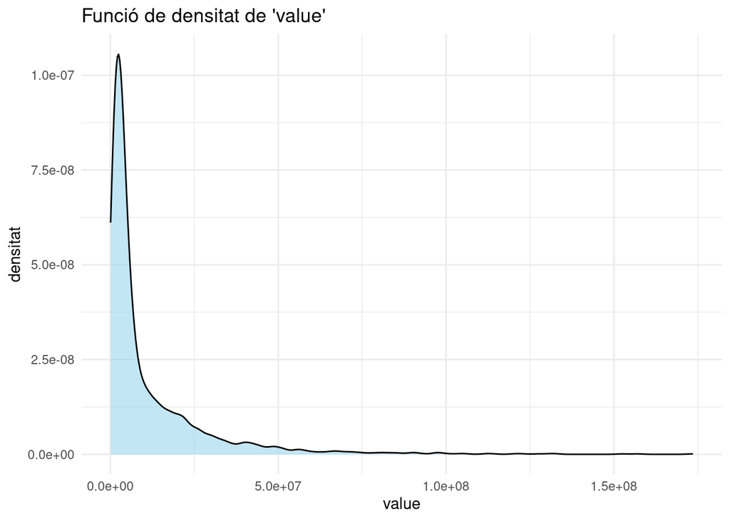

```r
library(ggplot2)
# Suposem que tens un dataframe anomenat df amb la columna value
ggplot(regdataset, aes(x = value)) +
  geom_density(fill = "skyblue", alpha = 0.5) +
  labs(title = "Funció de densitat de 'value'", x = "value", y = "densitat") +
  theme_minimal()
```

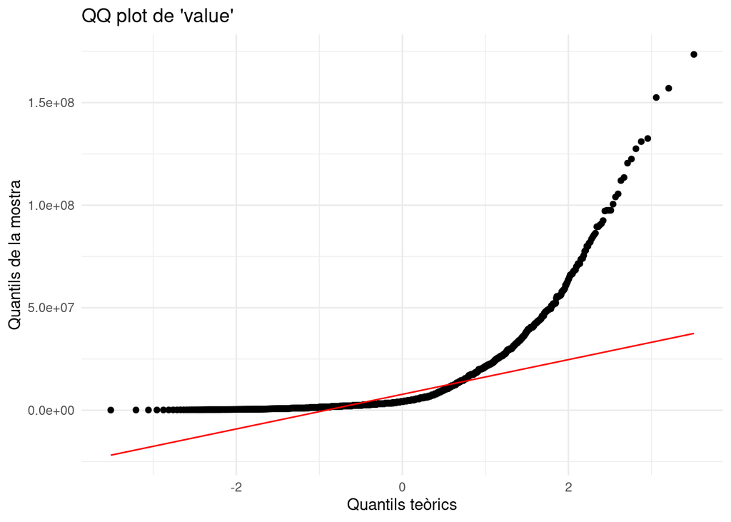

```r
ggplot(regdataset, aes(sample = value)) +
  stat_qq() +
  stat_qq_line(color = "red") +
  labs(title = "QQ plot de 'value'", x = "Quantils teòrics", y = "Quantils de la mostra") +
  theme_minimal()
```

Veiem que clarament no segueix una distribució normal ja que tenim una acumulació en els valors petits i desprès veiem que tenim una dispersió molt gran en els valors més gran. La idea de utilitzar la funció logarítmica sembla prometedora ja que creix més ràpid al principi per desprès creixer més lentament per tant podria normalitzar les dades.

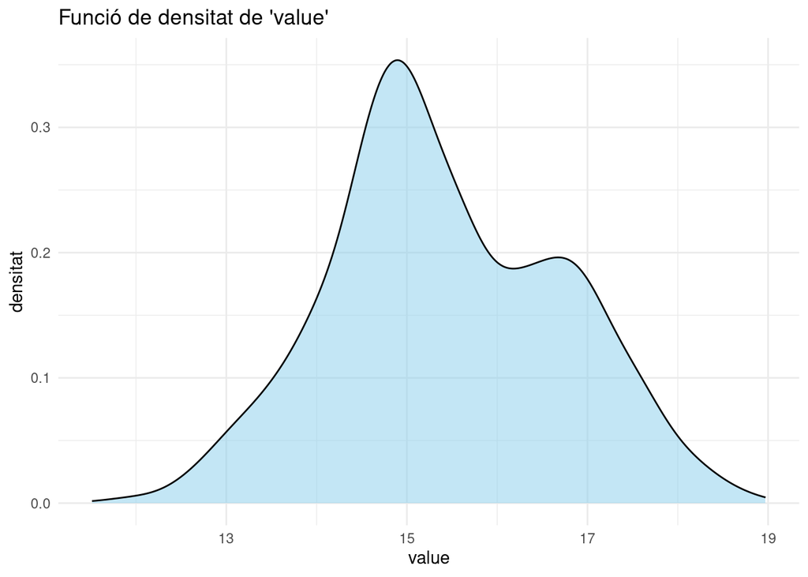

```r
ggplot(regdataset, aes(x = log(value))) +
  geom_density(fill = "skyblue", alpha = 0.5) +
  labs(title = "Funció de densitat de 'value'", x = "value", y = "densitat") +
  theme_minimal()
```

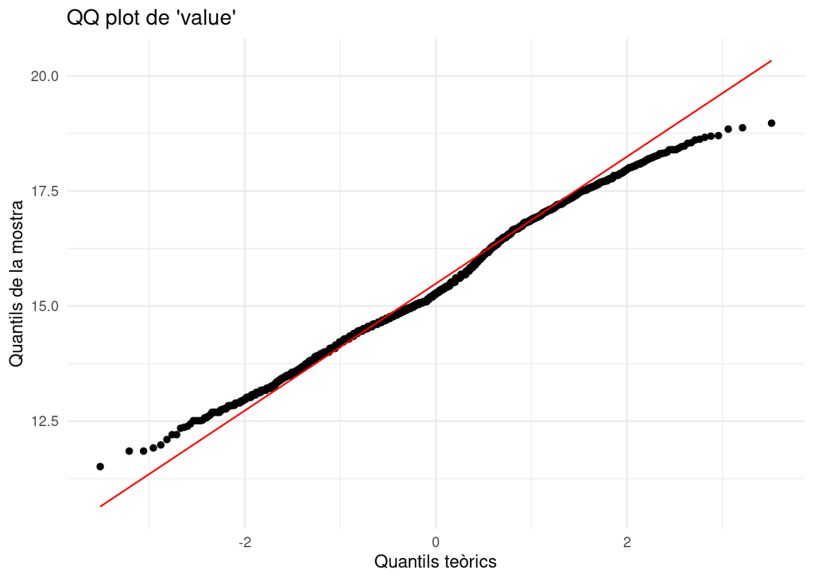

```r
ggplot(regdataset, aes(sample = log(value))) +
  stat_qq() +
  stat_qq_line(color = "red") +
  labs(title = "QQ plot de 'value'", x = "Quantils teòrics", y = "Quantils de la mostra") +
  theme_minimal()
```

```r
regdataset$lvalue <- log(regdataset$value)
regdataset <- regdataset[!is.na(regdataset$release_clause),]
```

### 3.2 Regressió lineal múltiple

Ajustar el model de regressió per a la variable dependent **value** en escala logarítmica. Denomineu a la variable depenent **lvalue**.

Interpreteu el model lineal ajustat. Com és la qualitat de l’ajust? Expliqueu breument la contribució de les variables explicatives en el model.

```r
smp_size <- floor(0.80 * nrow(regdataset))

## set the seed to make your partition reproducible
set.seed(123)
train_ind <- sample(seq_len(nrow(regdataset)), size = smp_size)

train <- regdataset[train_ind, ]
test <- regdataset[-train_ind, ]

model1 <- lm(lvalue ~ overall + potential + age + wage + release_clause, data = train )
summary(model1)
```

```
##
## Call:
## lm(formula = lvalue ~ overall + potential + age + wage + release_clause,
##     data = train)
##
## Residuals:
##      Min       1Q   Median       3Q      Max
## -2.57676 -0.13851  0.02707  0.18434  0.87763
##
## Coefficients:
##                  Estimate Std. Error t value Pr(>|t|)
## (Intercept)     2.031e+00  1.778e-01  11.419  < 2e-16 ***
## overall         1.926e-01  3.372e-03  57.122  < 2e-16 ***
## potential       1.526e-02  3.233e-03   4.720 2.55e-06 ***
## age            -8.463e-02  3.639e-03 -23.255  < 2e-16 ***
## wage            1.626e-04  3.875e-05   4.197 2.83e-05 ***
## release_clause  3.042e-10  3.884e-10   0.783    0.434
## ---
## Signif. codes:  0 '***' 0.001 '**' 0.01 '*' 0.05 '.' 0.1 ' ' 1
##
## Residual standard error: 0.3173 on 1767 degrees of freedom
## Multiple R-squared:   0.94,  Adjusted R-squared:  0.9398
## F-statistic:  5534 on 5 and 1767 DF,  p-value: < 2.2e-16
```

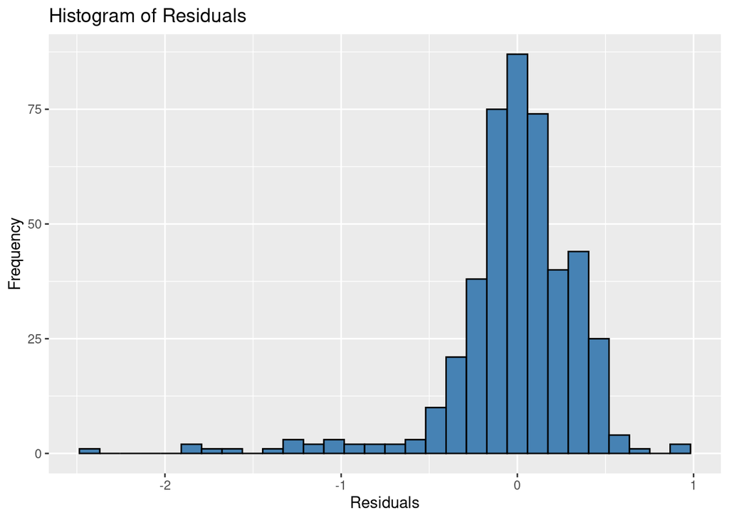

```r
predictions <- predict(model1, newdata = test)
residuals <-  test$lvalue - predictions
ggplot(data = test, aes(x = residuals)) +
    geom_histogram(fill = 'steelblue', color = 'black') +
    labs(title = 'Histogram of Residuals', x = 'Residuals', y = 'Frequency')
```

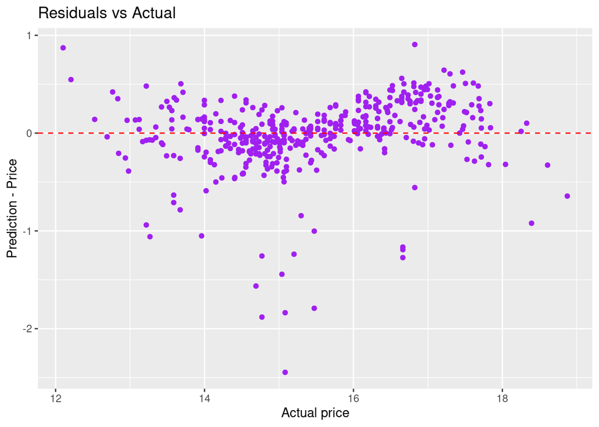

```r
library(ggplot2)

ggplot(data.frame(Actual = test$lvalue, Residuals = residuals), aes(x = Actual, y = Residuals)) +
  geom_point(color = "purple") +
  geom_hline(yintercept = 0, linetype = "dashed", color = "red") +
  labs(title = "Residuals vs Actual", x = "Actual price", y = "Prediction - Price")
```

```r
rmse <- sqrt(mean(residuals^2))
print(paste("RMSE:", round(rmse, 4)))
```

```
## [1] "RMSE: 0.3705"
```

Veiem que R² es 0.94 això indica que el 94% de la variabilitat en **lvalue** (logaritme del valor del jugador) es pot explicar amb les variables **overall**, **potential**, **age**, **wage** i **release_clause**.

La major part de les variables tenen una contribució estadísticament significativa. Les més rellevants són **overall**, **age**, i en menor mesura **potential** i **wage**. La variable **release_clause** no té efecte significatiu i es podria considerar prescindible.

### 3.3 Multicolinealitat

Analitzeu possibles problemes de multicolinealitat (alta correlació entre variables explicatives) mitjançant la interpretació de la matriu de correlacions i del factor d’inflació de la variància (vif). Es pot utilitzar la funció **vif** de la llibreria **car**.

```r
res <- cor(regdataset[,c( "overall", "potential", "age", "wage", "release_clause")])
kable(round(res, 2))
```

|  | overall | potential | age | wage | release_clause |
| --- | --- | --- | --- | --- | --- |
| overall | 1.00 | 0.68 | 0.51 | 0.73 | 0.72 |
| potential | 0.68 | 1.00 | -0.16 | 0.50 | 0.70 |
| age | 0.51 | -0.16 | 1.00 | 0.39 | 0.11 |
| wage | 0.73 | 0.50 | 0.39 | 1.00 | 0.81 |
| release_clause | 0.72 | 0.70 | 0.11 | 0.81 | 1.00 |

```r
library(car)
vif_values <- car::vif(model1)
kable(vif_values)
```

|  | x |
| --- | --- |
| overall | 8.691294 |
| potential | 5.489089 |
| age | 4.381246 |
| wage | 3.931912 |
| release_clause | 4.689781 |

Tenim variables molt correlacionades com per exemple **wage** i **release_clause** amb una correlació de 0.81, en general una correlacio més alta de 0.7 pot ser considerada alta, i tenim més exemples **overall** amb **wage** (0.73) i amb **release_clause** (0.72), i **potential** i **release_clause** (0.70).

Tenint en compte això tenim una multicolinealitat moderada on els parells més problemàtics són:

**overall** amb **wage** / **release_clause**

**wage** amb **release_clause**

El VIF nomes fa que confirmar la colinealitat, especialment per **overall**

## 4 ANOVA unifactorial

A continuació es realitzarà una anàlisi de variància, on es desitja comparar el valor de mercat de les jugadores entre les principals lligues.

L’anàlisi de variància consisteix a avaluar si la variabilitat d’una variable dependent pot explicar-se a partir d’una o diverses variables independents, denominades factors.

En el supòsit que ens ocupa, ens interessa avaluar si la variabilitat de la variable lvalue pot explicar-se pel tipus de lliga.

Hi ha dues preguntes bàsiques a respondre:

- Existeixen diferències en el valor de mercat (en escala logarítmica) entre les diferents lligues?
- Si existeixen diferències, entre quines lligues es donen aquestes diferències?

Per a realitzar aquest exercici, compararem entre sis lligues: SuperL, PrimeraD, FeminineD, Bundesliga, NWSL i la resta de lligues. Denomineu **league** a la variable categòrica amb aquests sis grups de lligues

```r
anova_unidataset <- ffemale_full[c("value", "league_name")]
anova_unidataset$lvalue <- log(anova_unidataset$value)
keywords <- c("Women's Super League", "Primera Division Women", "Feminine Division 1", "Bundesliga", "NWSL")
pattern <- paste(keywords, collapse = "|")
anova_unidataset <- anova_unidataset %>% mutate(league = ifelse(str_detect(league_name, pattern), league_name, "Resta"))
kable(head(anova_unidataset))
```

| value | league_name | lvalue | league |
| --- | --- | --- | --- |
| 127500000 | Primera Division Women | 18.66363 | Primera Division Women |
| 17250000 | Primera Division Women | 16.66332 | Primera Division Women |
| 120500000 | Primera Division Women | 18.60716 | Primera Division Women |
| 86338750 | Women’s Super League | 18.27379 | Women’s Super League |
| 97500000 | Primera Division Women | 18.39536 | Primera Division Women |
| 66000000 | NWSL | 18.00517 | NWSL |

### 4.1 Visualització gràfica

Mostreu gràficament la distribució de lvalue segons league representant els valors mitjans per a cada categoria. Es pot utilitzar la funció ggline de la llibreria ggpubr.

```r
library(ggpubr)

ggline(data = anova_unidataset, x = "league", y = "lvalue",
       add = "mean_se",         # Afegeix mitjana i error estàndard
       order = sort(unique(anova_unidataset$league)),  # Opcional: ordenar les categories
       ylab = "Mitjana de lvalue",
       xlab = "Lliga",
       title = "Mitjana de lvalue per league",
       color = "league",        # Diferents colors per categoria
       palette = "jco")  +
  theme(axis.text.x = element_text(angle = 21, hjust = 1))
```

```
## `geom_line()`: Each group consists of only one observation.
## ℹ Do you need to adjust the group aesthetic?
```

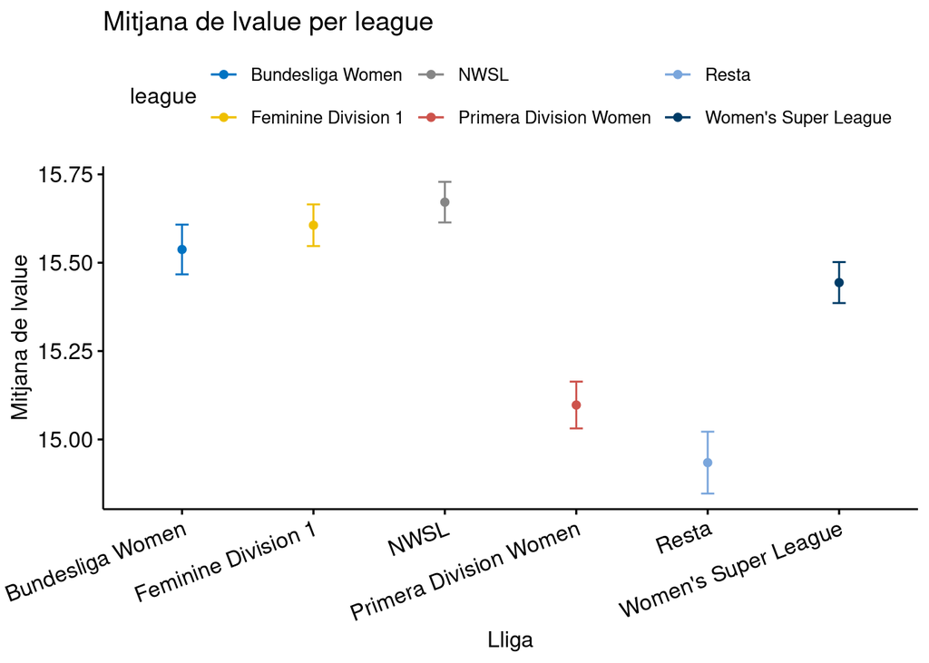

### 4.2 Hipòtesi nul·la i alternativa

Hipòtesis es que la diferencia entre la mitjana de cada un dels subgrups i la mitjana total es zero per a tots es a dir que si $\alpha_i = \mu-\mu_i$ on $ \mu_i$ es la mitjana dels que pertanyen a la classe $i$

$$H_0: \alpha_1 = \alpha_2 = \dots =
\alpha_6 = 0 \newline H_1: \alpha_i \ne \alpha_j \mbox{ per a algun }
i \ne j$$

### 4.3 Model

Realitzeu l’anàlisi de variància (ANOVA), utilitzant la funció **aov** i **lm**. Interpreteu el resultat de l’anàlisi.

```r
taov<-aov(lvalue~league,data=anova_unidataset)
summary(taov)
```

```
##               Df Sum Sq Mean Sq F value   Pr(>F)
## league         5    124  24.844   15.51 5.06e-15 ***
## Residuals   2239   3587   1.602
## ---
## Signif. codes:  0 '***' 0.001 '**' 0.01 '*' 0.05 '.' 0.1 ' ' 1
```

Obtenim un p-valor de l’ordre de e-15, clarament inferior a un nivell de significació del 5 %. Per tant, acceptem la hipòtesi alternativa i concloem que el factor és significatiu. És a dir, el tipus de lliga afecta a la valoració de la jugadora.

### 4.4 Aprofundint en ANOVA

A partir dels resultats del model retornat per **aov**, identifiqueu les variables SST (Total Sum of Squares), SSW (Within Sum of Squares), SSB (Between Sum of Squares) i els graus de llibertat. A partir d’aquests valors, calculeu manualment el valor F, el valor crític (a un nivell de confiança del 95%), i el valor p. Interpreteu els resultats i expliqueu el significat de les variables SST, SSW i SSB

SSB suma de quadrats dels tractaments = 124 es la variabilitat entre les mitjanes de cada **league** (efecte del factor)

SSW suma de quadrats de l’error = 3587 Variabilitat dins de cada **league** (error/residuals)

SST suma de quadrats total =124 + 3587 = 3711 es la variabilitat total de **lvalue**

Respecte els graus de llibertat tenim els de tractaments que son $a-1$ on $a$ es el numero de classes i els graus de llibertat del error $N-a$ on $N$ és el nombre total d’instàncies que tenim

$F=\frac{MSW}{MSB}=\frac{SSB / (a – 1)}{SSW / (N – a)}=\frac{124 / 5}{3587 / 2239}\simeq 15.51$

```r
qf(0.95, df1 = 5, df2 = 2239)
```

```
## [1] 2.218094
```

```r
pf(15.50, df1 = 5, df2 = 2239, lower.tail = FALSE)
```

```
## [1] 5.126361e-15
```

En resum com que:

### 4.5 Efectes dels nivells del factor i força de relació

Proporcioneu l’estimació de l’efecte dels nivells del factor **league**. Interpreteu els resultats.

```r
model.tables(taov, type = "effects")
```

```
## Tables of effects
##
##  league
##     Bundesliga Women Feminine Division 1     NWSL Primera Division Women
##               0.1099              0.1785   0.2438                -0.3302
## rep         303.0000            514.0000 324.0000               376.0000
##        Resta Women's Super League
##      -0.4932              0.01622
## rep 180.0000            548.00000
```

Veiem que tenim lligues que tenen un efecte positiu en el preu com la Bundesliga o la Feminine Division 1 en canvi també tenim lligues que tenen l’efecte contrari com la Primera Division Women o la categoria Resta on estan les lligues que no estaven a la llista

Calculeu la part de la variabilitat del valor de mercat (en log) explicada per l’efecte dels nivells (força de relació). És a dir, calculeu $\eta= \frac{SSB}{SST}$ del model. Interpreteu els resultats.

```r
SSB <- 124    # from aov summary (Sum Sq for league)
SSW <- 3587     # from residuals
SST <- SSB + SSW

eta2 <- SSB / SST
eta2
```

```
## [1] 0.03341417
```

$\eta^2 = 0.033$ per tant el 3.3% de la variabilitat del log del valor de mercat (**lvalue**) s’explica pel factor **league,** per tant la lliga a la que pertany una jugadora té una influencia baixa en el seu valor al mercat

## 5 Comparacions múltiples

Independentment del resultat obtingut en l’apartat anterior, realitzeu un test de comparació múltiple entre els grups amb correcció de Bonferroni. Aquest test s’aplica quan el test ANOVA retorna rebutjar la hipòtesi nul·la d’igualtat de mitjanes. Per tant, procedirem com si el test ANOVA hagués donat com a resultat el rebuig de la hipòtesi nul·la.

Calculeu les comparacions entre grups amb la correcció Bonferroni. Podeu utilitzar la funció pairwise.t.test. Interpreteu els resultats

```r
library(stats)
pairwise.t.test(anova_unidataset$lvalue,anova_unidataset$league, p.adj=c("bonferroni"))
```

```
##
##  Pairwise comparisons using t tests with pooled SD
##
## data:  anova_unidataset$lvalue and anova_unidataset$league
##
##                        Bundesliga Women Feminine Division 1 NWSL
## Feminine Division 1    1.00000          -                   -
## NWSL                   1.00000          1.00000             -
## Primera Division Women 0.00011          5.5e-08             3.8e-08
## Resta                  6.7e-06          1.6e-08             6.8e-09
## Women's Super League   1.00000          0.55357             0.15556
##                        Primera Division Women Resta
## Feminine Division 1    -                      -
## NWSL                   -                      -
## Primera Division Women -                      -
## Resta                  1.00000                -
## Women's Super League   0.00068                4.5e-05
##
## P value adjustment method: bonferroni
```

Veiem com tenim dos categories diferenciades, la de les lligues altes on podriem ajuntar Bundesliga Women, Feminine Division 1, NWSL i Women’s Super League que tindrien un lvalue més alt i Primera Division Women amb la resta que tindrien un valor més baix

## 6 ANOVA multifactorial

A continuació, es desitja avaluar l’efecte sobre **lvalue** de la lliga combinat amb si la jugadora és internacional. Seguiu els passos que s’indiquen a continuació.

### 6.1 Anàlisi visual dels efectes principals i possibles interaccions

Creeu una variable dicotòmica que indiqui si la jugadora és internacional a partir de si la jugadora té identificador en el seu equip nacional o no. Denomineu la variable **international**.

Dibuixeu en un gràfic la variable **value** (log) en funció de **league** i en funció de **international**. El gràfic ha de permetre avaluar si hi ha interacció entre els dos factors. Per això, es recomana seguir aquests passos:

1. Agrupeu el conjunt de dades per **league** i per **international**. Calculeu la mitjana del valor per a cada grup. Mostreu el conjunt de dades en forma de taula (data frame), on es mostri la mitjana de cada grup segons **league** i **international**, la desviació estàndard i el nombre d’observacions.
2. Mostreu en un gràfic el valor mitjà de la variable **lvalue** per a cada factor. Interpreteu el resultat sobre si només hi ha efectes principals o hi ha interacció entre els factors. Si hi ha interacció, expliqueu com s’observa aquesta interacció en el gràfic.

```r
anova_multdataset <- ffemale_full[c("value", "league_name","nation_team_id")]
anova_multdataset$lvalue <- log(anova_multdataset$value)
keywords <- c("Women's Super League", "Primera Division Women", "Feminine Division 1", "Bundesliga", "NWSL")
pattern <- paste(keywords, collapse = "|")
anova_multdataset <- anova_multdataset %>% mutate(league = ifelse(str_detect(league_name, pattern), league_name, "Resta"))
anova_multdataset <- anova_multdataset %>% mutate(international = ifelse(is.na(nation_team_id), "No", "Si"))
kable(head(anova_multdataset))
```

| value | league_name | nation_team_id | lvalue | league | international |
| --- | --- | --- | --- | --- | --- |
| 127500000 | Primera Division Women | 113012 | 18.66363 | Primera Division Women | Si |
| 17250000 | Primera Division Women | 113012 | 16.66332 | Primera Division Women | Si |
| 120500000 | Primera Division Women | 113007 | 18.60716 | Primera Division Women | Si |
| 86338750 | Women’s Super League | NA | 18.27379 | Women’s Super League | No |
| 97500000 | Primera Division Women | NA | 18.39536 | Primera Division Women | No |
| 66000000 | NWSL | 113009 | 18.00517 | NWSL | Si |

```r
summary_stats <- anova_multdataset %>%
  group_by(league, international) %>%
  summarise(
    mean_lvalue = mean(lvalue, na.rm = TRUE),
    sd_lvalue = sd(lvalue, na.rm = TRUE),
    n = n()
  ) %>%
  ungroup()
kable((summary_stats))
```

| league | international | mean_lvalue | sd_lvalue | n |
| --- | --- | --- | --- | --- |
| Bundesliga Women | No | 15.33395 | 1.0984629 | 271 |
| Bundesliga Women | Si | 17.26095 | 0.8166515 | 32 |
| Feminine Division 1 | No | 15.37859 | 1.1868635 | 459 |
| Feminine Division 1 | Si | 17.50453 | 0.9483352 | 55 |
| NWSL | No | 15.50662 | 0.9542457 | 281 |
| NWSL | Si | 16.74784 | 0.8874079 | 43 |
| Primera Division Women | No | 14.91606 | 1.1925551 | 336 |
| Primera Division Women | Si | 16.62026 | 0.9877938 | 40 |
| Resta | No | 14.79671 | 1.1442638 | 157 |
| Resta | Si | 15.87402 | 0.9385154 | 23 |
| Women’s Super League | No | 15.09985 | 1.2828921 | 413 |
| Women’s Super League | Si | 16.49596 | 0.9918399 | 135 |

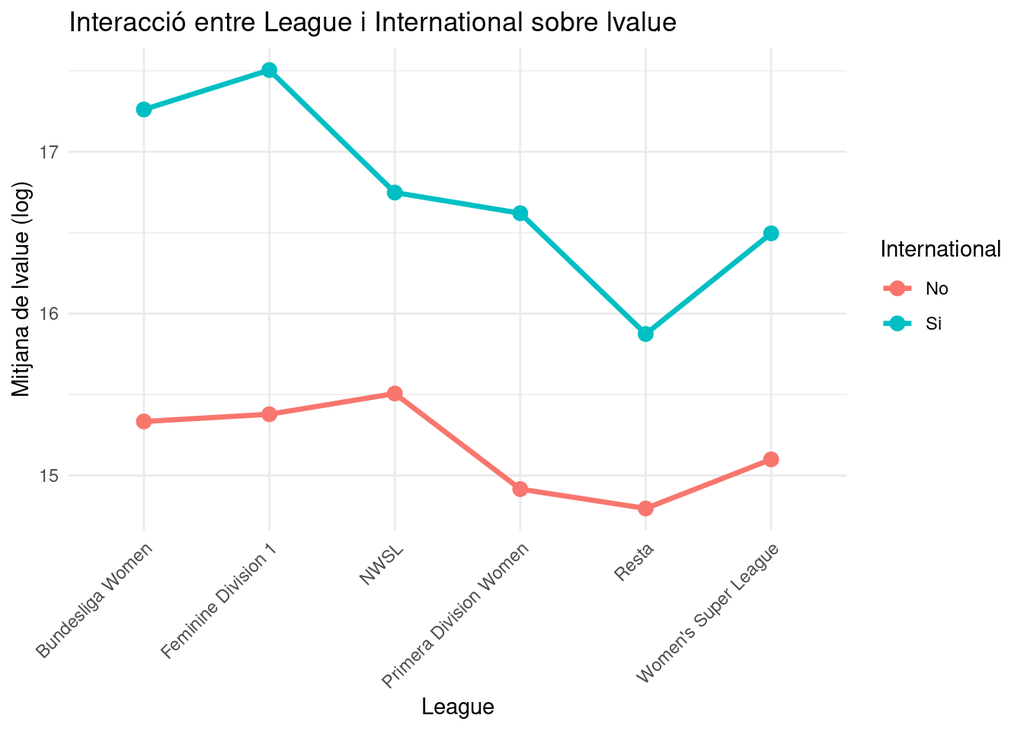

```r
library(ggplot2)

ggplot(summary_stats, aes(x = league, y = mean_lvalue, group = international, color = international)) +
  geom_line(size = 1.2) +
  geom_point(size = 3) +
  labs(
    title = "Interacció entre League i International sobre lvalue",
    x = "League",
    y = "Mitjana de lvalue (log)",
    color = "International"
  ) +
  theme_minimal() +
  theme(axis.text.x = element_text(angle = 45, hjust = 1))
```

Veiem com ser una jugadora internacional de mitjana afegeix valor a la jugadora, però també sembla que depenent de la lliga aquesta diferencia es més gran que altres, per exemple veiem que quan una jugadora esta a la NWSL i no va al internacional el seu valor es més alt que una jugadora que no va al internacional i esta a Division 1 encanvi si jugen internacionals es al reves. Per tant l’efecte d’haver estat jugadora internacional depèn de la lliga on juga.

### 6.2 Càlcul del model

Realitzeu l’anàlisi de la variància multifactorial sobre **lvalue** per a la combinació de **league** i **international**. Podeu utilitzar la funció **aov**

```r
taovmult <- aov(lvalue ~ league*international, data = anova_multdataset)
summary(taovmult)
```

```
##                        Df Sum Sq Mean Sq F value   Pr(>F)
## league                  5  124.2    24.8   19.29  < 2e-16 ***
## international           1  679.7   679.7  527.69  < 2e-16 ***
## league:international    5   31.4     6.3    4.88 0.000192 ***
## Residuals            2233 2876.2     1.3
## ---
## Signif. codes:  0 '***' 0.001 '**' 0.01 '*' 0.05 '.' 0.1 ' ' 1
```

### 6.3 Interpretació dels resultats

Tant **league** com **international** tenen efectes significatius sobre **lvalue**. A més, hi ha una interacció significativa, la qual cosa vol dir que l’impacte de ser internacional canvia segons la lliga. El model mostra que les dues variables i la seva interacció expliquen una part important de la variabilitat del valor de mercat.

## 7 Resum executiu

Escriviu un resum executiu com si haguéssiu de comunicar a una audiència no tècnica. Per exemple, podria ser un equip de managers, als quals els hi ha d’informar sobre les diferències en el valor de mercat de les jugadores.

Aquest estudi analitza com varien els valors de mercat (en logaritme) de les jugadores de futbol segons la lliga on juguen i si han estat internacionals (és a dir, si han representat la seva selecció nacional).

D’aquest anàlisis podem concloure que ser jugadora internacional té un impacte molt rellevant en el valor de mercat. Ja que les jugadores que han estat internacionals tenen, de mitjana, un valor de mercat significativament més alt.

També veiem que la lliga on juga la jugadora també importa, però menys. Degut a que hi ha diferències clares entre lligues, però aquestes són menys significatives en el valor de mercat.

Per últim considerar que la combinació dels dos factors (lliga i internacionalitat) també és important. Ja que l’impacte de ser internacional no és el mateix a totes les lligues. Per exemple, a lligues com la “Feminine Division 1” o la “Bundesliga Women”, ser internacional incrementa més el valor, comparat amb altres lligues.

Per tant a l’hora de valorar jugadores per a fitxatges o renovacions, s’ha de tenir molt en compte la seva trajectòria internacional. També es important saber en quina lliga juga ja que aquestes poden condicionar el valor, però el més important considerar com es combinen aquests factors, ja que una jugadora pot tenir un alt valor pel fet de jugar en una lliga concreta i ser internacional.